# Practical Work 3

Josep Ramon Ribera

Before all, we load the libraries we need.

```r
.libs <- c("doBy", "ggplot2", "arules")
sapply(.libs, require, character.only=TRUE)
```

#### 1. Read the file “nyt1.csv” and assign it to a variable “mydata”. Inspect the data (using the summary() function).

```r
mydata <- read.csv('nyt1.csv')
head(mydata)
```

```
##   Age Gender Impressions Clicks Signed_In
## 1  36      0           3      0         1
## 2  73      1           3      0         1
## 3  30      0           3      0         1
## 4  49      1           3      0         1
## 5  47      1          11      0         1
## 6  47      0          11      1         1
```

```r
summary(mydata)
```

```
##       Age             Gender       Impressions         Clicks
##  Min.   :  0.00   Min.   :0.000   Min.   : 0.000   Min.   :0.00000
##  1st Qu.:  0.00   1st Qu.:0.000   1st Qu.: 3.000   1st Qu.:0.00000
##  Median : 31.00   Median :0.000   Median : 5.000   Median :0.00000
##  Mean   : 29.48   Mean   :0.367   Mean   : 5.007   Mean   :0.09259
##  3rd Qu.: 48.00   3rd Qu.:1.000   3rd Qu.: 6.000   3rd Qu.:0.00000
##  Max.   :108.00   Max.   :1.000   Max.   :20.000   Max.   :4.00000
##    Signed_In
##  Min.   :0.0000
##  1st Qu.:0.0000
##  Median :1.0000
##  Mean   :0.7009
##  3rd Qu.:1.0000
##  Max.   :1.0000
```

#### 2. Create a new variable “age group” that categorizes users by age as “<20”,“20-29”,“30-39”,“40-49”,“50-59”,“>60”.

To categorize the users by age, we use the function discretize from the arules package.

```r
mydata$age_group <- discretize(mydata$Age, method = "fixed",
                               categories = c(-Inf, 20, 30, 40, 50, 60, Inf),
                               labels = c("<20", "20-29", "30-39", "40-49", "50-59", ">60"))
head(mydata)
```

```
##   Age Gender Impressions Clicks Signed_In age_group
## 1  36      0           3      0         1     30-39
## 2  73      1           3      0         1       >60
## 3  30      0           3      0         1     30-39
## 4  49      1           3      0         1     40-49
## 5  47      1          11      0         1     40-49
## 6  47      0          11      1         1     40-49
```

#### 3. Calculate the maximum and minimum values and the mean of attributes age, number of impressions and number of clicks for each age interval and for each gender (use the summaryBy function).

An easy way to perform this calculations is to use the function summaryBy from the doBy package.

```r
summaryBy(Age + Impressions + Clicks ~ age_group + Gender,
          data = mydata,
          FUN = list(mean, max, min))
```

```
##    age_group Gender  Age.mean Impressions.mean Clicks.mean Age.max
## 1        <20      0  1.151035         5.001456  0.13948410      19
## 2        <20      1 16.590316         4.988841  0.11411639      19
## 3      20-29      0 24.505557         5.000889  0.04916271      29
## 4      20-29      1 24.508804         4.984637  0.04813983      29
## 5      30-39      0 34.756556         5.018816  0.05191627      39
## 6      30-39      1 34.763281         5.012919  0.05176409      39
## 7      40-49      0 44.377839         5.006110  0.05250559      49
## 8      40-49      1 44.376731         5.022644  0.04997766      49
## 9      50-59      0 53.968780         5.002799  0.06902397      59
## 10     50-59      1 54.056409         5.026173  0.07169915      59
## 11       >60      0 68.946634         5.028799  0.13365718     108
## 12       >60      1 66.975656         5.003766  0.12683255     107
##    Impressions.max Clicks.max Age.min Impressions.min Clicks.min
## 1               18          4       0               0          0
## 2               17          3       7               0          0
## 3               16          2      20               0          0
## 4               16          2      20               0          0
## 5               17          2      30               0          0
## 6               20          3      30               0          0
## 7               17          2      40               0          0
## 8               17          2      40               0          0
## 9               15          3      50               0          0
## 10              15          3      50               0          0
## 11              16          3      60               0          0
## 12              16          3      60               0          0
```

#### 4. Build a histogram showing the total number of impresions for each age interval.

Using the summaryBy function we can prepare our data. Then with using the geom_histogram from ggplot2, we can show easily the data.

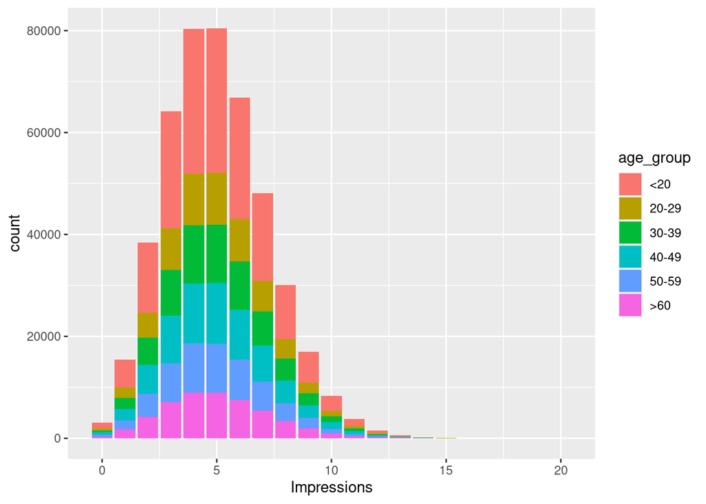

```r
impressions_table <- summaryBy(Impressions ~ age_group + Impressions,
                               data = mydata,
                               FUN = list(length))
ggplot(impressions_table, aes(x = Impressions, y = Impressions.length, fill = age_group)) +
  geom_histogram(stat = "identity") +
  labs(x = "Impressions", y = "count")
```

#### 5. Graphically show the distribution of the ratio clicks/impressions for each age interval and the distribution of clicks for each age group.

Before showing graphically the ratio clicks/impressions, we need first to filter the data to avoid the rows when the value for Impressions is 0.

```r
filtered_mydata <- mydata[mydata$Impressions != 0, ]
filtered_mydata$clicks_impressions <- filtered_mydata$Clicks / filtered_mydata$Impressions
```

Then, using the geom_density from ggplot2, we can easily show graphically the data.

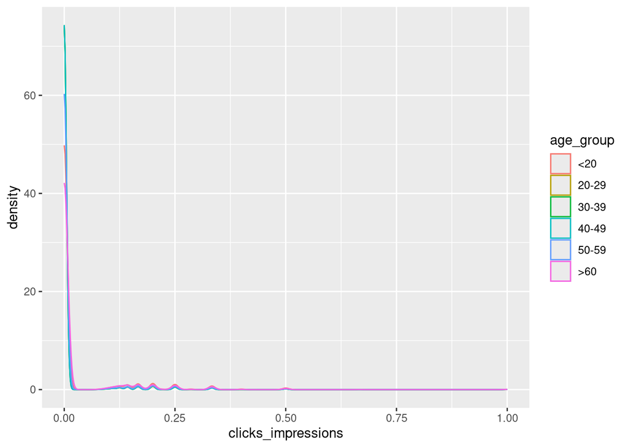

```r
ggplot(filtered_mydata, aes(x = clicks_impressions, color = age_group)) +
  geom_density()
```

Before showing the distributions of clicks, we need to filter the the data to avoid the rows when the value for Click is 0.

```r
filtered_mydata <- mydata[mydata$Clicks != 0, ]
```

Then, using the geom_density from ggplot2, we can easily show graphically the data.

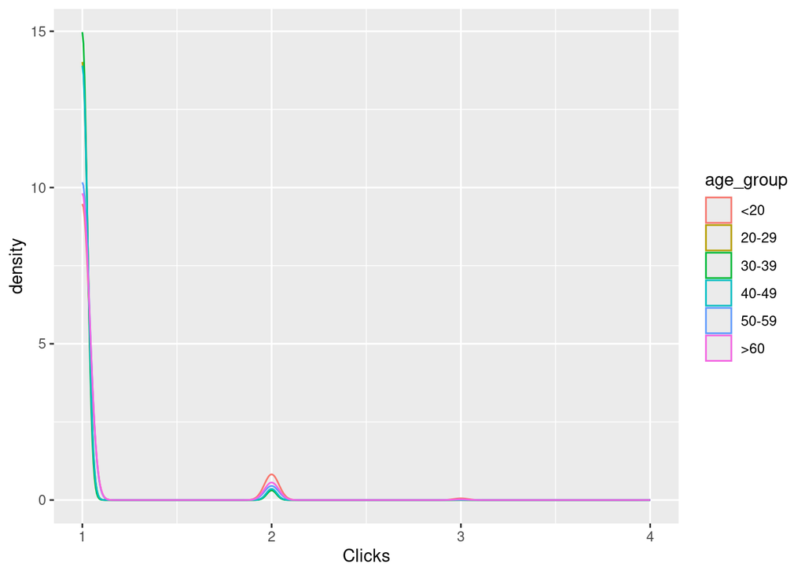

```r
ggplot(filtered_mydata, aes(x = Clicks, color = age_group)) +
  geom_density()
```